# Sparkify Project Workspace

This workspace contains a tiny subset (128MB) of the full dataset available (12GB). Feel free to use this workspace to build your project, or to explore a smaller subset with Spark before deploying your cluster on the cloud. Instructions for setting up your Spark cluster is included in the last lesson of the Extracurricular Spark Course content.

You can follow the steps below to guide your data analysis and model building portion of this project.

```python
# import libraries

import pandas as pd
import matplotlib.pyplot as plt
import time
import seaborn as sns
import numpy as np

from pyspark.sql import SparkSession
from pyspark.sql.functions import avg, col, concat, desc, explode, lit, min, max, split, udf
from pyspark.sql.types import IntegerType
from pyspark.sql.window import Window
from pyspark.sql.functions import udf, col, concat, count, lit, avg, lag, first, last, when
from pyspark.sql.functions import min as Fmin, max as Fmax, sum as Fsum, round as Fround

import datetime

from pyspark.ml import Pipeline
from pyspark.ml.classification import LogisticRegression
from pyspark.ml.evaluation import MulticlassClassificationEvaluator
from pyspark.ml.feature import CountVectorizer, IDF, Normalizer, PCA, RegexTokenizer, StandardScaler, StopWordsRemover, StringIndexer, VectorAssembler
from pyspark.ml.regression import LinearRegression
from pyspark.ml.tuning import CrossValidator, ParamGridBuilder
from pyspark.ml.classification import LogisticRegression, RandomForestClassifier, GBTClassifier
from pyspark.ml.tuning import CrossValidator, ParamGridBuilder
from pyspark.ml.evaluation import BinaryClassificationEvaluator, Evaluator

import re
```

```python
# create a Spark session
spark = SparkSession.builder.master("local").appName("Spark Project").getOrCreate()
```

# Load and Clean Dataset

In this workspace, the mini-dataset file is `mini_sparkify_event_data.json`. Load and clean the dataset, checking for invalid or missing data - for example, records without userids or sessionids.

```python
df = spark.read.json('mini_sparkify_event_data.json')
```

## Data Exploration

First let's load a few samples to have a look at the data:

```python
df.take(2)
```

```
[Row(artist='Martha Tilston', auth='Logged In', firstName='Colin', gender='M', itemInSession=50, lastName='Freeman', length=277.89016, level='paid', location='Bakersfield, CA', method='PUT', page='NextSong', registration=1538173362000, sessionId=29, song='Rockpools', status=200, ts=1538352117000, us…
 Row(artist='Five Iron Frenzy', auth='Logged In', firstName='Micah', gender='M', itemInSession=79, lastName='Long', length=236.09424, level='free', location='Boston-Cambridge-Newton, MA-NH', method='PUT', page='NextSong', registration=1538331630000, sessionId=8, song='Canada', status=200, ts=1538352…
```

Let's print the schema of the data:

```python
df.printSchema()
```

```
root
 |-- artist: string (nullable = true)
 |-- auth: string (nullable = true)
 |-- firstName: string (nullable = true)
 |-- gender: string (nullable = true)
 |-- itemInSession: long (nullable = true)
 |-- lastName: string (nullable = true)
 |-- length: double (nullable = true)
 |-- level: string (nullable = true)
 |-- location: string (nullable = true)
 |-- method: string (nullable = true)
 |-- page: string (nullable = true)
 |-- registration: long (nullable = true)
 |-- sessionId: long (nullable = true)
 |-- song: string (nullable = true)
 |-- status: long (nullable = true)
 |-- ts: long (nullable = true)
 |-- userAgent: string (nullable = true)
 |-- userId: string (nullable = true)
```

Let's drop any row having missing values either for userId or sessionId:

```python
df_valid = df.dropna(how = "any", subset = ["userId", "sessionId"])
```

```python
df_valid.count(), df.count()
```

```
(286500, 286500)
```

We see that there are no missing values neither in the userId nor in the sessionId fields.

Let's further explore the userId field:

```python
all_users_id = df.select('userId').distinct().sort("userId")
```

```python
all_users_id.show(5)
```

```
+------+
|userId|
+------+
|      |
|    10|
|   100|
|100001|
|100002|
+------+
only showing top 5 rows
```

We see that there is this blank " " userId that seems strange. Let's further check the corresponding pages to understand more:

```python
# filter for users with blank user id
blank_pages = df.filter(df.userId == '') \
    .select(col('page') \
    .alias('blank_pages')) \
    .dropDuplicates()

set(blank_pages.collect())
```

```
{Row(blank_pages='About'),
 Row(blank_pages='Error'),
 Row(blank_pages='Help'),
 Row(blank_pages='Home'),
 Row(blank_pages='Login'),
 Row(blank_pages='Register'),
 Row(blank_pages='Submit Registration')}
```

We see that no songs have been played at all by this userId. This seems to correspond to unregistered users. We can then drop this userId safely:

```python
df_valid = df_valid.filter(df_valid["userId"] != "")
```

```python
df_valid.count()
```

```
278154
```

Below we create the userId structure:

```python
all_users_id = df_valid.select('userId').distinct().sort("userId")
```

```python
all_users_id.show(5)
```

```
+------+
|userId|
+------+
|    10|
|   100|
|100001|
|100002|
|100003|
+------+
only showing top 5 rows
```

# Exploratory Data Analysis

When you're working with the full dataset, perform EDA by loading a small subset of the data and doing basic manipulations within Spark. In this workspace, you are already provided a small subset of data you can explore.

### Define Churn

Once you've done some preliminary analysis, create a column `Churn` to use as the label for your model. I suggest using the `Cancellation Confirmation` events to define your churn, which happen for both paid and free users. As a bonus task, you can also look into the `Downgrade` events.

### Explore Data

Once you've defined churn, perform some exploratory data analysis to observe the behavior for users who stayed vs users who churned. You can start by exploring aggregates on these two groups of users, observing how much of a specific action they experienced per a certain time unit or number of songs played.

### Find Churners

```python
df_at_churn = df_valid.filter(df_valid['page'] == 'Cancellation Confirmation')
```

```python
df_at_churn.take(2)
```

```
[Row(artist=None, auth='Cancelled', firstName='Adriel', gender='M', itemInSession=104, lastName='Mendoza', length=None, level='paid', location='Kansas City, MO-KS', method='GET', page='Cancellation Confirmation', registration=1535623466000, sessionId=514, song=None, status=200, ts=1538943990000, use…
 Row(artist=None, auth='Cancelled', firstName='Diego', gender='M', itemInSession=56, lastName='Mckee', length=None, level='paid', location='Phoenix-Mesa-Scottsdale, AZ', method='GET', page='Cancellation Confirmation', registration=1537167593000, sessionId=540, song=None, status=200, ts=1539033046000…
```

Find the identities of the churners:

```python
churned_user_id = df_at_churn.select('userId').distinct()
```

```python
num_churned = churned_user_id.count()
num_users = all_users_id.count()
```

```python
print('Found {} churners over a total of {} users ({:0.1f}%)'.format(num_churned, num_users, num_churned/num_users*100))
```

```
Found 52 churners over a total of 225 users (23.1%)
```

```python
print('Found {} loyal users over a total of {} users ({:0.1f}%)'.format(num_users - num_churned, num_users, (1-num_churned/num_users)*100))
```

```
Found 173 loyal users over a total of 225 users (76.9%)
```

Now let's convert churned_user_id to a list for easier manipulation:

```python
churner_users_list = [row['userId'] for row in churned_user_id.collect()]
all_users_list = [row['userId'] for row in all_users_id.collect()]
loyal_users_list = list(set(all_users_list) - set(churner_users_list))
len(churner_users_list), len(loyal_users_list)
```

```
(52, 173)
```

Adding a column with 'Churn' event (we should keep in mind that the column is only filled for the moments where the user is churning);

```python
df_valid = df_valid.withColumn('Churn', (df_valid['page'] == 'Cancellation Confirmation').cast(IntegerType()))
```

## Some more data exploration

### Let's determine the period over which the dateframe was collected

```python
start_date_default = df_valid.select([min("ts")]).withColumnRenamed('min(ts)', 'minvalue').collect()[0].minvalue
end_date_default = df_valid.select([max("ts")]).withColumnRenamed('max(ts)', 'maxvalue').collect()[0].maxvalue
```

```python
start_date_default_str = datetime.datetime.fromtimestamp(start_date_default/1e3).strftime("%A, %B %d, %Y %I:%M:%S")
end_date_default_str = datetime.datetime.fromtimestamp(end_date_default/1e3).strftime("%A, %B %d, %Y %I:%M:%S")
```

```python
print('Date of the first observation in the dataframe : '+start_date_default_str)
print('Date of the last observation in the dataframe : '+end_date_default_str)
```

```
Date of the first observation in the dataframe : Monday, October 01, 2018 12:01:57
Date of the last observation in the dataframe : Monday, December 03, 2018 01:11:16
```

### Let's check at the different actions a user can do to interact with the application:

```python
all_pages = df_valid.select('page').distinct()
```

```python
all_pages.show()
```

```
+--------------------+
|                page|
+--------------------+
|              Cancel|
|    Submit Downgrade|
|         Thumbs Down|
|                Home|
|           Downgrade|
|         Roll Advert|
|              Logout|
|       Save Settings|
|Cancellation Conf...|
|               About|
|            Settings|
|     Add to Playlist|
|          Add Friend|
|            NextSong|
|           Thumbs Up|
|                Help|
|             Upgrade|
|               Error|
|      Submit Upgrade|
+--------------------+
```

```python
all_pages_list = [row['page'] for row in all_pages.collect()]
print(all_pages_list)
```

```
['Cancel', 'Submit Downgrade', 'Thumbs Down', 'Home', 'Downgrade', 'Roll Advert', 'Logout', 'Save Settings', 'Cancellation Confirmation', 'About', 'Settings', 'Add to Playlist', 'Add Friend', 'NextSong', 'Thumbs Up', 'Help', 'Upgrade', 'Error', 'Submit Upgrade']
```

```python
pages_dist = df_valid.groupBy('page').count().sort('count')
pages_dist.show()
```

```
+--------------------+------+
|                page| count|
+--------------------+------+
|              Cancel|    52|
|Cancellation Conf...|    52|
|    Submit Downgrade|    63|
|      Submit Upgrade|   159|
|               Error|   252|
|       Save Settings|   310|
|               About|   495|
|             Upgrade|   499|
|                Help|  1454|
|            Settings|  1514|
|           Downgrade|  2055|
|         Thumbs Down|  2546|
|              Logout|  3226|
|         Roll Advert|  3933|
|          Add Friend|  4277|
|     Add to Playlist|  6526|
|                Home| 10082|
|           Thumbs Up| 12551|
|            NextSong|228108|
+--------------------+------+
```

We could push further the exploration of the dataset but we will instead consider another constructed dataset because of the following considerations:

- The churners stop using the application earlier than loyal user. Therefore, they will by construction generate less activity.
- Furthermore, using the dataset as is introduces some data leakage. Actually, we use data of users *after* they churned. We should instead use the data *before* they churned.
- We thus cannot consider the absolute values of the variables as useful features.
- Instead, we should determine some user profile with actions per unit of time computed on the time they are active on the application.
- Therefore, we will use the following path:
  - First, we will construct variables that do not produce any leakage
  - Then we will do some data exploration on the constructed data set
  - Finally, we will construct a model to predict the churn

**Defining a statistical unit for our study**  
The goal of the study is to predict whether a user will churn. Since the decision is user-based, we should consider that the elementary unit of our study is a user. We should therefore construct a dataframe indexed by the user where each column is a feature describing how the user interacts with the application.

We will construct the different features below.

# Feature construction and data exploration

We will now construct some features describing how the users interact with the application.  
As stated below, we should avoid features introducing a leakage. The first step is to determine the time of interaction for each user.

## Determining the experiment time duration of a user

We want to build features such as the number of songs played per unit of time. To do so, we should consider only the period of time a user can perform the action. This means:

- After the user registered
- Before the user churned

We therefore need to determine, for each user, those two dates to compute the duration we use to compute the various features.

There are two cases to consider in order to compute the experiment time duration of a user:

- If the user registered before the first element of the dataframe, we should start its obervation at the beginning of the dataframe. Otherwise, we should use the registration time.
- If a user did not churn, we should end its observation window at the end of the dataframe. Otherwise, we should use the time of churn.

We will construct the observation window of each user following these rules.

```python
def get_active_hours(df_in = df_valid):
    """
    Computes the duration of the observation time of each user.

    IN:
    df_in : dataframe construted to include the start and end date of each user

    OUT:
    df_active_hours : Dataframe with observation window duration of each window in hours

    """

    ms_per_hour = 3600000

    # Get the registration table of each user
    registration_table = df_in.select('userId', 'registration') \
    .groupBy('userId') \
    .agg({'registration':'first'}) \
    .withColumnRenamed('first(registration)', 'registration') \

    # For users that registered before the start of the dataFrame, take the start of the dataframe as the
    # start of the observation window : registration_used
    registration_table = registration_table.withColumn("registration_used", \
        when(registration_table.registration<start_date_default, start_date_default) \
        .otherwise(registration_table.registration))

    # Get the last action of a user and its time stamp
    df_end_state = df_in.select('userId', 'page', 'ts') \
    .groupBy('userId') \
    .agg({'ts':'max', 'page':'last'}) \
    .withColumnRenamed('last(page)', 'last_action') \
    .withColumnRenamed('max(ts)', 'last_ts') \

    # For users that did not churn, take the end of the observation window as the end of the dataframe
    df_end_state = df_end_state.withColumn("last_ts_used", \
        when(df_end_state.last_action == 'Cancellation Confirmation', df_end_state.last_ts)
        .otherwise(end_date_default))

    # Join two tables
    df_obs_window = registration_table.join(df_end_state, on=['userId'], how='left')

    # Get the observation windows durations for each users
    df_obs_window = df_obs_window.withColumn('active_hours', \
     ( df_obs_window.last_ts_used - df_obs_window.registration_used  ) / ms_per_hour )

    df_active_hours = df_obs_window.select('userId', 'active_hours')

    return df_active_hours

df_active_hours = get_active_hours(df_valid)
df_active_hours.show(10)
```

```
+------+------------------+
|userId|      active_hours|
+------+------------------+
|100010|1513.1552777777779|
|200002|1513.1552777777779|
|   125|268.55583333333334|
|   124|1513.1552777777779|
|    51|391.62638888888887|
|     7|1513.1552777777779|
|    15|1513.1552777777779|
|    54|1027.6363888888889|
|   155| 674.7238888888888|
|100014|1219.0366666666666|
+------+------------------+
only showing top 10 rows
```

## Feature construction : user activity per unit of time

```python
def add_page_feature(page_feature_name, df_in, df_events = df_valid):
    """
    Add the specific feature 'page_feature_name' to the df_in dataframe.
    The df_in dataframe is indexed by the userId and contains actions per hours.
    The function computes the total number of times the action 'page_feature_name' id executed, and divide the value
    by the obervation window duration of the user.

    IN:
    page_feature_name : the feature to be considered.
    df_in : The df_in dataframe indexed by the userId and containing actions per hours.
    df_events : the original (cleaned) dataframe containing all the events.

    OUT:
    df_in completed with the page_feature_name column
    """

    df_count = df_events.select('userId', 'page').filter(df_events.page == page_feature_name).groupBy('userId').count()
    df_in = df_in.join(df_count, on=['userId'], how='left')
    df_in = df_in.withColumn('_'.join(page_feature_name.split())+'_per_hour', df_in['count']/df_in['active_hours'] )
    df_in = df_in.drop('count')
    df_in = df_in.fillna(0)

    return df_in
```

```python
def add_num_actions_hour_feature(df_in, df_events = df_valid):
    """
    Count the total number of interactions per hour for the different users.
    The df_in dataframe is indexed by the userId and contains actions per hours.

    IN:
    df_in : The df_in dataframe indexed by the userId and containing actions per hours.
    df_events : the original (cleaned) dataframe containing all the events.

    OUT:
    df_in completed with the act_per_hour column giving the total number of interactions per hour for the different users.
    """

    df_count = df_events.select('userId', 'page').groupBy('userId').count()
    df_in = df_in.join(df_count, on=['userId'], how='left')
    df_in = df_in.withColumn('act_per_hour', df_in['count']/df_in['active_hours'] )
    df_in = df_in.drop('count')

    return df_in
```

## Features construction : gender table and churn label

```python
def get_churn_table(df_in = df_valid):
    """
    Compute a table indexed by userId identifying the users that churned.

    IN:
    df_in : the original (cleaned) dataframe containing all the events.

    OUT:
    A dataframe indexed by userId identifying the users that churned.
    """

    churn_table = df_in.select('userId', 'Churn').distinct()
    churn_table = churn_table.groupBy('userId').max().withColumnRenamed('max(Churn)', 'Churn')
    return churn_table
```

```python
def get_gender_table(df_in = df_valid):
    """
    Compute a table indexed by userId identifying the gender of the users.

    IN:
    df_in : the original (cleaned) dataframe containing all the events.

    OUT:
    A dataframe indexed by userId identifying the gender of the users.
    """

    gender_table = df_valid.select('userId', 'gender').distinct()
    gender_table = gender_table.withColumn('gender_int', (gender_table['gender'] == 'F').cast(IntegerType()))
    gender_table = gender_table.drop('gender')
    gender_table = gender_table.withColumnRenamed('gender_int', 'gender')
    return gender_table
```

## Feature construction : user activity per visit

```python
# User defined function equal to 1 when the page is 'Home'
ishome_function = udf(lambda ishome : int(ishome == 'Home'), IntegerType())

user_window = Window \
    .partitionBy('userID') \
    .orderBy(desc('ts')) \
    .rangeBetween(Window.unboundedPreceding, 0)

def get_num_songs_per_visit(df_in = df_valid, user_window = user_window):
    """
    Gives the average number of songs played per visit for a given user.

    IN:
    df_in : the original (cleaned) dataframe containing all the events.
    user_window : user specific window indexed by the time.

    OUT:
    songs_per_visit : A dataframe indexed by userId identifying the average number of songs played per visit.
    """

    cusum = df_in.filter((df_in.page == 'NextSong') | (df_in.page == 'Home')) \
        .select('userID', 'page', 'ts') \
        .withColumn('homevisit', ishome_function(col('page'))) \
        .withColumn('period', Fsum('homevisit').over(user_window))

    songs_per_visit = cusum.filter((cusum.page == 'NextSong')) \
        .groupBy('userID', 'period') \
        .agg({'period':'count'}) \
        .select('userId', 'count(period)') \
        .groupBy('userId') \
        .mean() \
        .withColumnRenamed('avg(count(period))', 'songs_per_visit')

    return songs_per_visit
```

```python
songs_per_visit = get_num_songs_per_visit(df_valid)
songs_per_visit.show(5)
```

```
+------+------------------+
|userId|   songs_per_visit|
+------+------------------+
|100010|22.916666666666668|
|200002|             19.35|
|   125|               8.0|
|   124|  24.4251497005988|
|    51|29.319444444444443|
+------+------------------+
only showing top 5 rows
```

```python
def get_num_items_per_visit(df_in = df_valid):
    """
    Gives the average number of interactions per visit for a given user.

    IN:
    df_in : the original (cleaned) dataframe containing all the events.

    OUT:
    songs_per_visit : A dataframe indexed by userId identifying the average number of songs played per visit.
    """

    items_per_visit = df_valid.groupby(['userId', 'sessionId'])\
    .agg(Fmax(col('itemInSession')).alias('num_items'))\
    .groupby('userId').agg(avg(col('num_items')).alias('items_per_visit'))

    return items_per_visit
```

```python
items_per_visit = get_num_items_per_visit(df_valid)
items_per_visit.show(5)
```

```
+------+------------------+
|userId|   items_per_visit|
+------+------------------+
|100010| 54.42857142857143|
|200002|              80.0|
|   125|              10.0|
|    51|             251.9|
|   124|170.13793103448276|
+------+------------------+
only showing top 5 rows
```

```python
def get_num_hours_per_visit(df_in = df_valid):
    """
    Gives the average visit duration in hours for a given user.

    IN:
    df_in : the original (cleaned) dataframe containing all the events.

    OUT:
    hours_per_visit : A dataframe indexed by userId identifying average visit duration in hours.
    """

    ms_per_hour = 3600000

    hours_per_visit = df_valid.groupby(['userId', 'sessionId'])\
    .agg(Fmin(col('ts')).alias('session_start'), Fmax(col('ts')).alias('session_end'))\
    .groupby('userId')\
    .agg((avg(col('session_end')-col('session_start'))/ms_per_hour).alias('hours_per_visit'))

    return hours_per_visit
```

```python
hours_per_visit = get_num_hours_per_visit(df_valid)
hours_per_visit.show(5)
```

```
+------+-------------------+
|userId|    hours_per_visit|
+------+-------------------+
|100010| 2.5747222222222224|
|200002|               4.44|
|   125|0.49277777777777776|
|    51| 14.539277777777778|
|   124|  9.649904214559388|
+------+-------------------+
only showing top 5 rows
```

## Combine all previous functions to get the final dataframe with all features

```python
selected_page_features = ['Thumbs Down', 'Home', 'Roll Advert', 'Save Settings', \
                          'About', 'Settings', 'Add to Playlist', 'Add Friend', 'NextSong', 'Thumbs Up', \
                          'Help', 'Error']

def get_features(df_in=df_valid, page_features = selected_page_features):
    """
    Combine all previous functions to get the final dataframe with all features

    IN:
    df_in : the original (cleaned) dataframe containing all the events.
    page_features : the 'page' features we will consider

    OUT:
    df_features : A dataframe indexed by userId with all features we want to consider.
    """

    df_active_hours = get_active_hours()

    df_features = df_active_hours
    for feature in page_features:
        df_features = add_page_feature(feature, df_features)

    df_features = add_num_actions_hour_feature(df_features)

    songs_per_visit = get_num_songs_per_visit(df_in)
    df_features = df_features.join(songs_per_visit, on=['userId'], how='left')

    items_per_visit = get_num_items_per_visit(df_in)
    df_features = df_features.join(items_per_visit, on=['userId'], how='left')

    hours_per_visit = get_num_hours_per_visit(df_in)
    df_features = df_features.join(hours_per_visit, on=['userId'], how='left')

    gender_table = get_gender_table(df_in)
    df_features = df_features.join(gender_table, on=['userId'], how='left')

    churn_table = get_churn_table(df_in)
    df_features = df_features.join(churn_table, on=['userId'], how='left')

    df_features = df_features.drop('active_hours')

    return df_features
```

```python
all_features_df = get_features(df_valid, selected_page_features)
```

## Features visualization

#### Get some high level statistics of features per user type (churner / loyal)

```python
def get_features_stats(feature_name, df_in = all_features_df):

    print('FEATURE : ' + feature_name)
    print('Loyal users:')
    print(df_in.filter(df_in.Churn == 0).select(feature_name).describe().show())
    print('Churners:')
    print(df_in.filter(df_in.Churn == 1).select(feature_name).describe().show())

    pass
```

```python
final_features = ['Thumbs_Down_per_hour', 'Home_per_hour', 'Roll_Advert_per_hour',\
             'Save_Settings_per_hour', 'About_per_hour', 'NextSong_per_hour', 'Settings_per_hour', \
             'Add_Friend_per_hour', 'Thumbs_Up_per_hour', 'Help_per_hour', 'Error_per_hour',\
             'songs_per_visit', 'hours_per_visit', 'gender', 'Churn']
```

```python
set(all_features_df.columns) - set(final_features)
```

```
{'Add_to_Playlist_per_hour', 'act_per_hour', 'items_per_visit', 'userId'}
```

#### Plot correlation to visualize multi-colinearity

```python
pd_features_df = all_features_df.toPandas()
```

```python
features =  all_features_df.columns[1:]
print(features)
```

```
['Thumbs_Down_per_hour', 'Home_per_hour', 'Roll_Advert_per_hour', 'Save_Settings_per_hour', 'About_per_hour', 'Settings_per_hour', 'Add_to_Playlist_per_hour', 'Add_Friend_per_hour', 'NextSong_per_hour', 'Thumbs_Up_per_hour', 'Help_per_hour', 'Error_per_hour', 'act_per_hour', 'songs_per_visit', 'item…
```

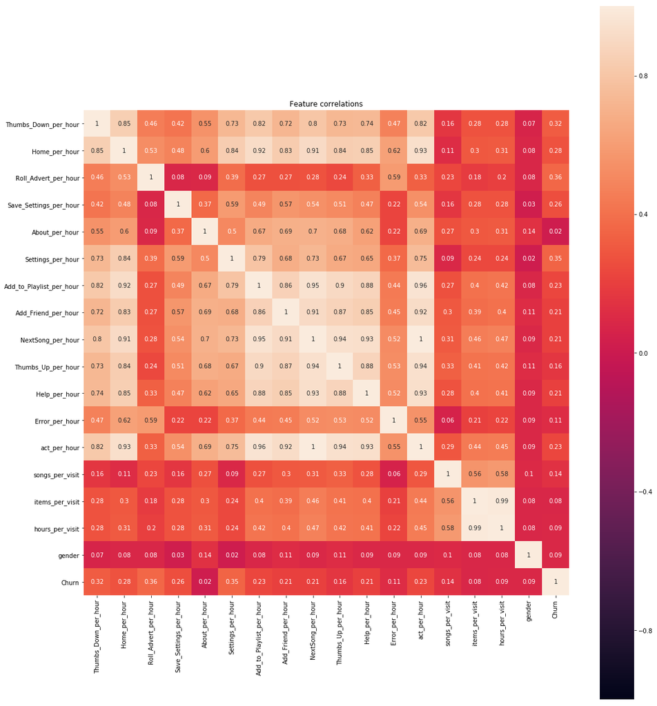

```python
# Calculate correlations between numerical features
import numpy as np
cormat = np.round(pd_features_df[features].corr(), 2)

# Plot correlations
plt.rcParams['figure.figsize'] = (20,20)
plt.subplots_adjust(left=0.20, right=0.9, top=0.95, bottom=0.15)
sns.heatmap(np.abs(cormat), annot=True, square = True, vmin = -1, vmax = 1);
plt.title('Feature correlations');
plt.savefig('correlations.png')
```

### Feature selection based on correlation matrix

We see that some features have very high correlations with others. In particular, the following features seem to be highly correlated with multiple other ones;

- 'Home_per_hour'
- 'Add_to_Playlist_per_hour'
- 'act_per_hour'

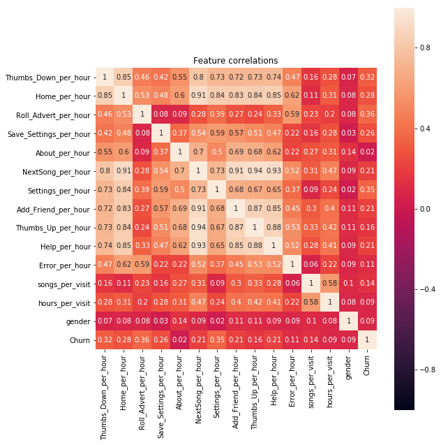

```python
final_features = ['Thumbs_Down_per_hour', 'Home_per_hour', 'Roll_Advert_per_hour',\
             'Save_Settings_per_hour', 'About_per_hour', 'NextSong_per_hour', 'Settings_per_hour', \
             'Add_Friend_per_hour', 'Thumbs_Up_per_hour', 'Help_per_hour', 'Error_per_hour',\
             'songs_per_visit', 'hours_per_visit', 'gender', 'Churn']

cormat_final = np.round(pd_features_df[final_features].corr(), 2)

# Plot correlations
plt.rcParams['figure.figsize'] = (10,10)
plt.subplots_adjust(left=0.20, right=0.9, top=0.95, bottom=0.15)
sns.heatmap(np.abs(cormat_final), annot=True, square = True, vmin = -1, vmax = 1);
plt.title('Feature correlations');
plt.savefig('correlations.png')
```

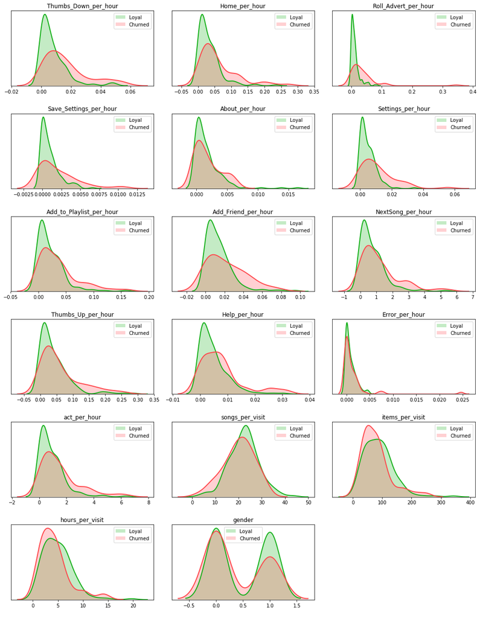

```python
# One dimensionnal analysis

selected_features = features[:-1]

# Define colors to use throughout this notebook
colors = ['green', 'light red']
palette = sns.xkcd_palette(colors)
color1 = palette[0]
color2 = palette[1]

# Define plotting parameters
plt.rcParams['figure.figsize'] = (14,18)


for i in range(len(selected_features)):
    plt.subplot(6,3,i+1)
    plt.tight_layout();
    sns.distplot(pd_features_df[pd_features_df['Churn'] == 0][selected_features[i]], hist = False, norm_hist = True,
                 kde_kws = {'shade': True, 'linewidth': 2}, color = color1);
    sns.distplot(pd_features_df[pd_features_df['Churn'] == 1][selected_features[i]], hist = False, norm_hist = True,
                 kde_kws = {'shade': True, 'linewidth': 2}, color = color2);
    plt.legend(['Loyal','Churned']);
    plt.title(selected_features[i]);
    plt.xlabel(" ");
    plt.yticks([]);
```

# Modeling

Split the full dataset into train, test, and validation sets. Test out several of the machine learning methods you learned. Evaluate the accuracy of the various models, tuning parameters as necessary. Determine your winning model based on test accuracy and report results on the validation set. Since the churned users are a fairly small subset, I suggest using F1 score as the metric to optimize.

```python
df_user_features = all_features_df.select(*final_features)
df_user_features = df_user_features.withColumnRenamed('Churn', 'label')
```

```python
#  F1 score evaluator
class F1_score(Evaluator):
    """
    F1 score evaluation to be used for model evaluation and grid-search

    """

    def __init__(self, predictionCol = "prediction", labelCol="label"):
        self.predictionCol = predictionCol
        self.labelCol = labelCol

    def _evaluate(self, dataset):

        eps = 0.0001

        # F1 score
        true_pos = dataset.where((dataset.label == 1) & (dataset.prediction == 1)).count()
        false_pos = dataset.where((dataset.label == 0) & (dataset.prediction == 1)).count()
        true_neg = dataset.where((dataset.label == 0) & (dataset.prediction == 0)).count()
        false_neg = dataset.where((dataset.label == 1) & (dataset.prediction == 0)).count()

        # Add epsilon to prevent division by zero
        precision = true_pos / float(true_pos + false_pos + eps)
        recall = true_pos / float(true_pos + false_neg + eps)

        f1 = 2 * precision * recall / float(precision + recall + eps)

        return f1

    def isLargerBetter(self):
        return True
```

```python
# Get numerical features
numeric_features = final_features.copy()
numeric_features.remove('gender')
numeric_features.remove('Churn')

num_assembler = VectorAssembler(inputCols = numeric_features, outputCol = "num_vectorized")

#  numerical features normalization
scaler = StandardScaler(inputCol = 'num_vectorized', outputCol = 'num_scaled', withStd = True, withMean = True)

# Adding the gender
final_assembler = VectorAssembler(inputCols =  ['gender'] + ['num_scaled'], outputCol = "features")
```

```python
df_train, df_test = df_user_features.randomSplit([0.8, 0.2], seed = 42)
```

```python
spark.conf.set("spark.sql.broadcastTimeout",-1)
```

## LogisticRegression

```python
# Grid search by fitting the grid search object
log_classif = LogisticRegression()
pipeline_log = Pipeline(stages = [num_assembler, scaler, final_assembler, log_classif])

start = time.time()
model_log = pipeline_log.fit(df_train)
end = time.time()
print('Time spent for training:')
print(round(end-start))
```

```
Time spent for training:
313
```

```python
# Obtain predictions on the test set
results_log = model_log.transform(df_test)
```

```python
# AUC score on the test set
auc_evaluator = BinaryClassificationEvaluator()
auc_out_log = auc_evaluator.evaluate(results_log)
print('Model logistic regression AUC score:')
print(auc_out_log)
```

```
Model logistic regression AUC score:
0.7707509881422926
```

```python
# F1 score on the test set
f1_evaluator = F1_score()
f1score_log = f1_evaluator._evaluate(results_log)
print('Logistic regression F1 score:')
print(f1score_log)
```

```
Logistic regression F1 score:
0.47053702861759505
```

```python
print(results_log.filter(results_log.label == results_log.prediction).count()/results_log.count())
```

```
0.7058823529411765
```

#### Grid search for logistic regression:

```python
# Grid search by fitting the grid search object
f1_evaluator = F1_score()
log_classif = LogisticRegression()
pipeline_log = Pipeline(stages = [num_assembler, scaler, final_assembler, log_classif])
```

```python
paramGrid_log = ParamGridBuilder() \
.addGrid(log_classif.regParam,[0, 0.8]) \
.addGrid(log_classif.elasticNetParam,[0, 0.8]) \
.build()

crossval_log = CrossValidator(estimator=pipeline_log,
                          estimatorParamMaps=paramGrid_log,
                          evaluator=f1_evaluator,
                          numFolds=3)
```

```python
cvModel_log = crossval_log.fit(df_train)
```

```python
cvModel_log.avgMetrics
```

```
[0.49585198095826466, 0.49585198095826466, 0.13688582429724236, 0.0]
```

```python
cvresults_log = cvModel_log.transform(df_test)
```

```python
print(cvresults_log.filter(cvresults_log.label == cvresults_log.prediction).count()/cvresults_log.count())
```

[output not shown]

```python
# AUC score on the test set
auc_evaluator = BinaryClassificationEvaluator()
cvauc_out_log = auc_evaluator.evaluate(cvresults_log)
print('Model logistic regression AUC score:')
print(cvauc_out_log)
```

```
Model logistic regression AUC score:
0.7707509881422926
```

```python
f1_evaluator = F1_score()
cvf1score_log = f1_evaluator._evaluate(cvresults_log)
print('Model F1 score:')
print(cvf1score_log)
```

```
Model F1 score:
0.47053702861759505
```

```python
BinaryClassificationEvaluator?
```

## Random Forest classifier

```python
# Grid search by fitting the grid search object
rf_classif = RandomForestClassifier()
pipeline_rf = Pipeline(stages = [num_assembler, scaler, final_assembler, rf_classif])

start = time.time()
model_rf = pipeline_rf.fit(df_train)
end = time.time()
print('Time spent for training:')
print(round(end-start))
```

```
Time spent for training:
446
```

```python
# Obtain predictions on the test set
results_rf = model_rf.transform(df_test)
```

```python
# AUC score on the test set
auc_evaluator = BinaryClassificationEvaluator()
auc_out_rf = auc_evaluator.evaluate(results_rf)
print('Random Forest AUC score:')
print(auc_out_rf)
```

```
Random Forest AUC score:
0.7588932806324111
```

```python
# F1 score on the test set
f1_evaluator = F1_score()
f1score_rf = f1_evaluator._evaluate(results_rf)
print('Random Forest F1 score:')
print(f1score_rf)
```

```
Random Forest F1 score:
0.4999507848447321
```

```python
print(results_rf.filter(results_rf.label == results_rf.prediction).count()/results_rf.count())
```

```
0.7647058823529411
```

#### Feature importance of Random Forest classifier:

```python
# Display feature importances
importances_rf = model_rf.stages[-1].featureImportances
importances_rf_list = [importances_rf[i] for i in range(len(importances_rf))]
names = ['gender'] + numeric_features
```

```python
importances_rf_list = np.array(importances_rf_list)
```

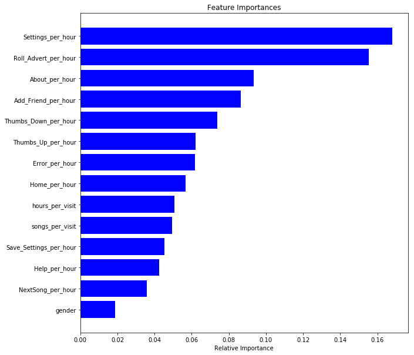

```python
import numpy as np
indices = np.argsort(importances_rf_list)

fig, ax = plt.subplots(figsize=(10,10))
plt.title('Feature Importances')
plt.barh(range(len(indices)), importances_rf_list[indices], color='b', align='center')
plt.yticks(range(len(indices)), [names[i] for i in indices])
plt.xlabel('Relative Importance')
plt.show()
```

#### Grid search for Random Forest classifier:

```python
rf_classif = RandomForestClassifier()
pipeline_rf = Pipeline(stages = [num_assembler, scaler, final_assembler, rf_classif])

paramGrid_rf = ParamGridBuilder() \
    .addGrid(rf_classif.maxDepth,[3, 5]) \
    .addGrid(rf_classif.numTrees,[20, 50]) \
    .build()

crossval_rf = CrossValidator(estimator=pipeline_rf,
                          estimatorParamMaps=paramGrid_rf,
                          evaluator=f1_evaluator,
                          numFolds=3)
```

```python
cvModel_rf = crossval_rf.fit(df_train)
```

```python
cvModel_rf.avgMetrics
```

```
[0.2777469737270036,
 0.30154509272160196,
 0.4747658826006572,
 0.35974176735231067]
```

```python
cvresults_rf = cvModel_rf.transform(df_test)
```

```python
cvresults_rf = cvModel_rf.bestModel.transform(df_test)
```

```python
print(cvresults_rf.filter(cvresults_rf.label == cvresults_rf.prediction).count()/cvresults_rf.count())
```

```
0.7058823529411765
```

```python
# AUC score on the test set
auc_evaluator = BinaryClassificationEvaluator()
cvauc_out_rf = auc_evaluator.evaluate(cvresults_rf)
print('Model logistic regression AUC score:')
print(cvauc_out_rf)
```

```
Model logistic regression AUC score:
0.6778656126482213
```

```python
# F1 score on the test set
f1score = f1_evaluator._evaluate(cvresults_rf)
print('Model Random Forest F1 score:')
print(f1score)
```

```
Model Random Forest F1 score:
0.6095938375350142
```

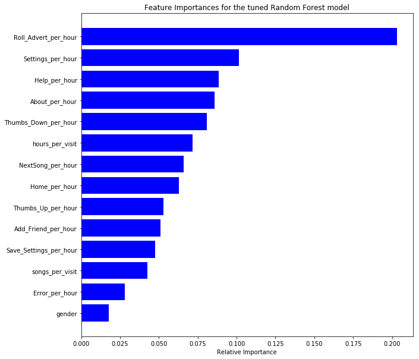

```python
# Display feature importances
importances_rf_cv = cvModel_rf.bestModel.stages[-1].featureImportances
importances_rf_cv_list = [importances_rf_cv[i] for i in range(len(importances_rf_cv))]
names = ['gender'] + numeric_features
importances_rf_cv_list = np.array(importances_rf_cv_list)

indices = np.argsort(importances_rf_cv_list)

fig, ax = plt.subplots(figsize=(10,10))
plt.title('Feature Importances for the tuned Random Forest model')
plt.barh(range(len(indices)), importances_rf_cv_list[indices], color='b', align='center')
plt.yticks(range(len(indices)), [names[i] for i in indices])
plt.xlabel('Relative Importance')
plt.show()
```

## Gradient-Boosted tree classifier

```python
# Grid search by fitting the grid search object
gb_classif = GBTClassifier()
pipeline = Pipeline(stages = [num_assembler, scaler, final_assembler, gb_classif])

start = time.time()
model = pipeline.fit(df_train)
end = time.time()
print('Time spent for training:')
print(round(end-start))
```

```
Time spent for training:
568
```

```python
# Obtain predictions on the test set
results = model.transform(df_test)
```

```python
# AUC score on the test set
auc_evaluator = BinaryClassificationEvaluator()
auc_out = auc_evaluator.evaluate(results)
print('Gradient-Boosted tree classifier AUC score:')
print(auc_out)
```

```
Gradient-Boosted tree classifier AUC score:
0.592885375494071
```

```python
# F1 score on the test set
f1_evaluator = F1_score()
f1score = f1_evaluator._evaluate(results)
print('Gradient-Boosted tree classifier F1 score:')
print(f1score)
```

```
Gradient-Boosted tree classifier F1 score:
0.3157374036564071
```

```python
print(results.filter(results.label == results.prediction).count()/results.count())
```

```
0.6176470588235294
```

#### Feature importance of Gradient-Boosted tree classifier:

```python
# Display feature importances
importances = model.stages[-1].featureImportances
importances_list = [importances[i] for i in range(len(importances))]
names = ['gender'] + numeric_features
```

```python
importances_list = np.array(importances_list)
```

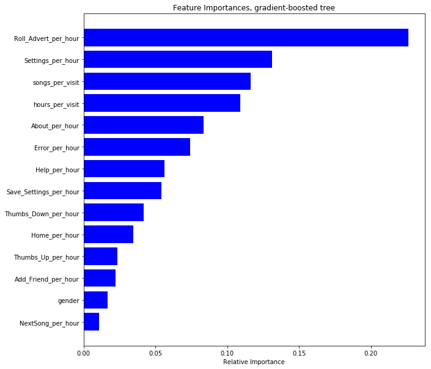

```python
import numpy as np
indices = np.argsort(importances_list)

fig, ax = plt.subplots(figsize=(10,10))
plt.title('Feature Importances, gradient-boosted tree')
plt.barh(range(len(indices)), importances_list[indices], color='b', align='center')
plt.yticks(range(len(indices)), [names[i] for i in indices])
plt.xlabel('Relative Importance')
plt.show()
```

#### Grid search for Gradient-Boosted tree classifier:

```python
gb_classif = GBTClassifier()
pipeline = Pipeline(stages = [num_assembler, scaler, final_assembler, gb_classif])

paramGrid = ParamGridBuilder() \
    .addGrid(gb_classif.maxDepth,[4, 5, 6]) \
    .build()


crossval = CrossValidator(estimator=pipeline,
                          estimatorParamMaps=paramGrid,
                          # evaluator=MulticlassClassificationEvaluator(),
                          evaluator=f1_evaluator,
                          numFolds=3)
```

```python
cvModel = crossval.fit(df_train)
```

```python
cvModel.avgMetrics
```

```
[0.7619720258970386, 0.7497922276207345, 0.7379429651599667]
```

```python
cvresults = cvModel.transform(df_test)
```

```python
print(cvresults.filter(cvresults.label == cvresults.prediction).count()/cvresults.count())
```

```
0.6470588235294118
```

```python
# AUC score on the test set
auc_evaluator = BinaryClassificationEvaluator()
cvauc_out = auc_evaluator.evaluate(cvresults)
print('Gradient-Boosted tree classifier AUC score:')
print(cvauc_out)
```

[output not shown]

```python
# F1 score on the test set
f1score = f1_evaluator._evaluate(cvresults)
print('Model F1 score:')
print(f1score)
```

```
Model F1 score:
0.6367647058823528
```

```python
# Display feature importances
importances = cvModel.bestModel.stages[-1].featureImportances
importances_list = [importances[i] for i in range(len(importances))]
names = ['gender'] + numeric_features
```

```python
importances_list = np.array(importances_list)
```

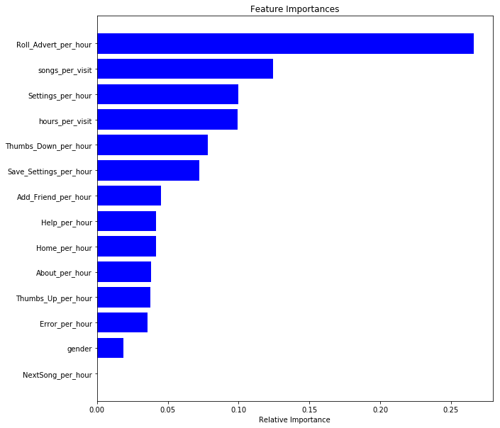

```python
fig, ax = plt.subplots(figsize=(10,10))
indices = np.argsort(importances_list)
plt.title('Feature Importances')
plt.barh(range(len(indices)), importances_list[indices], color='b', align='center')
plt.yticks(range(len(indices)), [names[i] for i in indices])
plt.xlabel('Relative Importance')
plt.show()
```

# Final Steps

Clean up your code, adding comments and renaming variables to make the code easier to read and maintain. Refer to the Spark Project Overview page and Data Scientist Capstone Project Rubric to make sure you are including all components of the capstone project and meet all expectations. Remember, this includes thorough documentation in a README file in a Github repository, as well as a web app or blog post.